# Testing the interactions terms in the models of gene expression

J. Ignacio Lucas Lledó

# Interaction between selective regime and hatching condition

## Model 6

```r
qlf6 <- glmQLFTest(fit6, coef=4)
topTags(qlf6)
```

```
## Coefficient:  regimerandom:diapausediapause
##                  logFC     logCPM        F      PValue       FDR
## XLOC_024210 -2.4456751 -1.5271896 15.55546 0.004605562 0.9998194
## XLOC_029615  0.9438359  5.1117353 15.31782 0.004800492 0.9998194
## XLOC_034421 -1.6537942 -0.7614238 13.26311 0.007010684 0.9998194
## XLOC_029614  0.7651341  4.3502569 12.56990 0.008038787 0.9998194
## XLOC_025062 -1.7375444 -0.7541641 12.40875 0.008304635 0.9998194
## XLOC_020818  0.6104000  6.1257989 12.18356 0.008695084 0.9998194
## XLOC_045709  0.8500404  7.3552494 12.16057 0.008736232 0.9998194
## XLOC_049254 -3.1327600 -1.7547226 11.83037 0.009355502 0.9998194
## XLOC_009802 -1.5751722 -0.7860737 11.34519 0.010369981 0.9998194
## XLOC_040002 -1.5088722 -0.8357054 10.77032 0.011759650 0.9998194
```

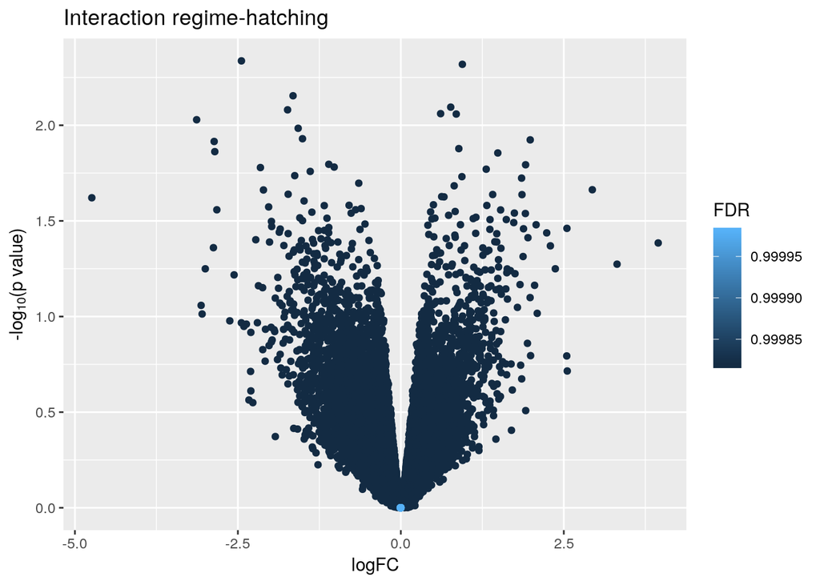

```r
z1 <- topTags(qlf6, n=NumOfTags)$table
z1$logPValue <- -log10(z1$PValue)
ggplot(data=z1, mapping=aes(x=logFC, y=logPValue, color=FDR)) +
   geom_point() + theme_grey() + ylab(expression(paste("-log"[10], plain("(p value)")))) +
   ggtitle('Interaction regime-hatching')
```

According to model 6, there are 0 tags with a significant interaction term between selective regime and hatching condition at FDR = 0.25.

## Model 5

```r
qlf5 <- glmQLFTest(fit5, coef=4)
topTags(qlf5)
```

```
## Coefficient:  regimerandom:diapausediapause
##                  logFC     logCPM         F      PValue       FDR
## XLOC_024210 -2.4315157 -1.5288213 14.668733 0.002554398 0.9999704
## XLOC_009802 -1.5876502 -0.7871982 13.976584 0.003007000 0.9999704
## XLOC_040002 -1.5020404 -0.8356154 12.813476 0.003999777 0.9999704
## XLOC_020167 -2.9274569 -1.6229634 12.629838 0.004189766 0.9999704
## XLOC_034421 -1.6632933 -0.7631284 11.254892 0.006007371 0.9999704
## XLOC_044803  2.2898771  1.3809934 10.998002 0.006442977 0.9999704
## XLOC_043930  1.9173729 -1.7783709 10.673413 0.007047922 0.9999704
## XLOC_051217 -2.7884765 -1.3106881  9.212432 0.010760719 0.9999704
## XLOC_051241 -0.8044339  4.0345554  9.019197 0.011409157 0.9999704
## XLOC_030765  2.5647431 -1.8677254  8.974542 0.011565526 0.9999704
```

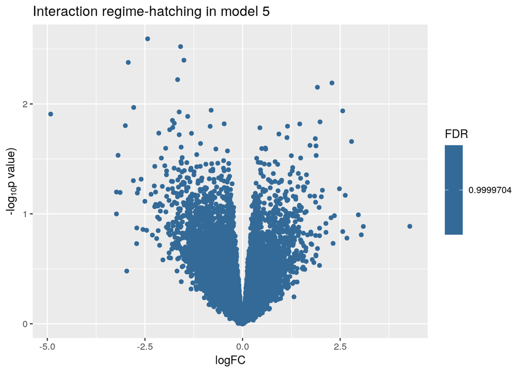

```r
z1 <- topTags(qlf5, n=NumOfTags)$table
z1$logPValue <- -log10(z1$PValue)
ggplot(data=z1, mapping=aes(x=logFC, y=logPValue, color=FDR)) +
   geom_point() + theme_grey() + ylab(expression(paste("-log"[10], plain("p value)")))) +
   ggtitle('Interaction regime-hatching in model 5')
```

According to model 5, there are 0 tags with a significant interaction term between selective regime and hatching condition at FDR = 0.25. And this is how models 5 and 6 agree on what genes have such significant interaction term:

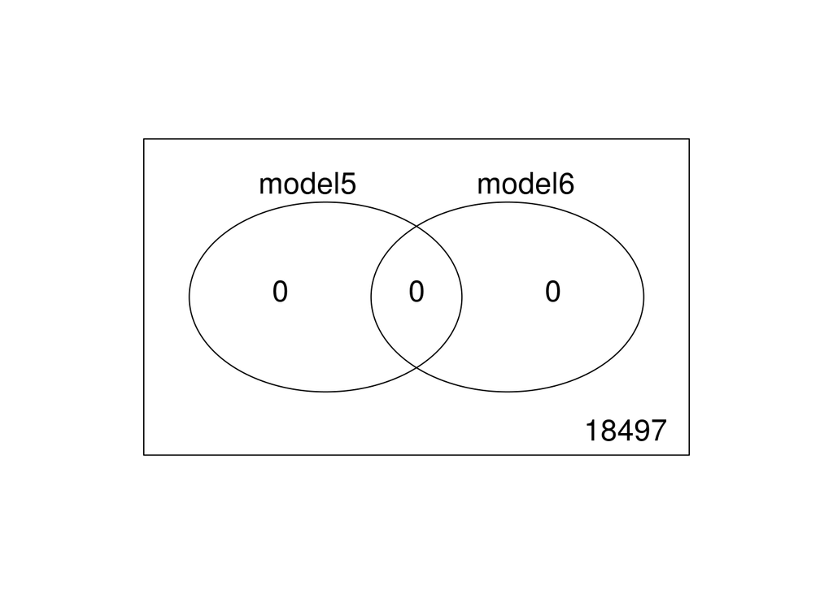

```r
significant <- cbind(model5 = topTags(qlf5, n=NumOfTags, sort.by='none')$table$FDR <= 0.25,
                     model6 = topTags(qlf6, n=NumOfTags, sort.by='none')$table$FDR <= 0.25)
vennDiagram(vennCounts(significant))
```

# Interaction between selective regime and population

When testing for significant coefficients showing the effect of the nested population, there are not one but 4 possible coefficients, each with a different fold change. For the volcano plot, I want to use for each gene the fold change that is most extreme (either positive or negative).

## Model 6

```r
qlf6  <- glmQLFTest(fit6, coef=5:8)
topTags(qlf6)
```

```
## Coefficient:  regimeregular:NestedPop2 regimerandom:NestedPop2 regimeregular:NestedPop3 regimerandom:NestedPop3
##             logFC.regimeregular.NestedPop2 logFC.regimerandom.NestedPop2
## XLOC_017180                     -0.5333835                   -2.37175684
## XLOC_001420                      0.6579139                    0.20077271
## XLOC_020688                     -2.7007688                    3.00443751
## XLOC_018218                     -0.6086934                   -3.72876583
## XLOC_044910                      1.1213577                   -6.37988314
## XLOC_020921                     -1.0612256                    2.40337952
## XLOC_031557                      0.3136556                   -0.07845153
## XLOC_044284                      0.2139017                   -3.84114250
## XLOC_016593                     -0.1878020                    2.32269680
## XLOC_031928                     -2.6973907                   -3.35114756
##             logFC.regimeregular.NestedPop3 logFC.regimerandom.NestedPop3
## XLOC_017180                    -1.45434082                     6.6626442
## XLOC_001420                     0.22957285                     2.2849336
## XLOC_020688                    -0.93160432                    -0.1785064
## XLOC_018218                     0.03406936                    -1.9803567
## XLOC_044910                     0.79545835                     0.3778997
## XLOC_020921                    -0.41787152                     2.2150580
## XLOC_031557                     0.29517354                    -3.7733669
## XLOC_044284                     0.18027177                    -0.4072234
## XLOC_016593                     0.42114057                     1.1601085
## XLOC_031928                    -1.27354445                     0.8327480
##               logCPM         F       PValue         FDR
## XLOC_017180 2.028242 114.34713 6.625782e-07 0.008774226
## XLOC_001420 6.601577  93.39464 1.420066e-06 0.008774226
## XLOC_020688 4.257620  93.34199 1.423078e-06 0.008774226
## XLOC_018218 4.493171  78.97010 2.663740e-06 0.012317802
## XLOC_044910 2.180257  66.71030 4.998997e-06 0.015650489
## XLOC_020921 4.827533  65.96669 5.211885e-06 0.015650489
## XLOC_031557 4.128848  63.73638 5.922767e-06 0.015650489
## XLOC_044284 5.617176  56.52216 9.245204e-06 0.020959552
## XLOC_016593 4.501459  55.04180 1.019819e-05 0.020959552
## XLOC_031928 1.353020  50.94923 1.356103e-05 0.025083830
```

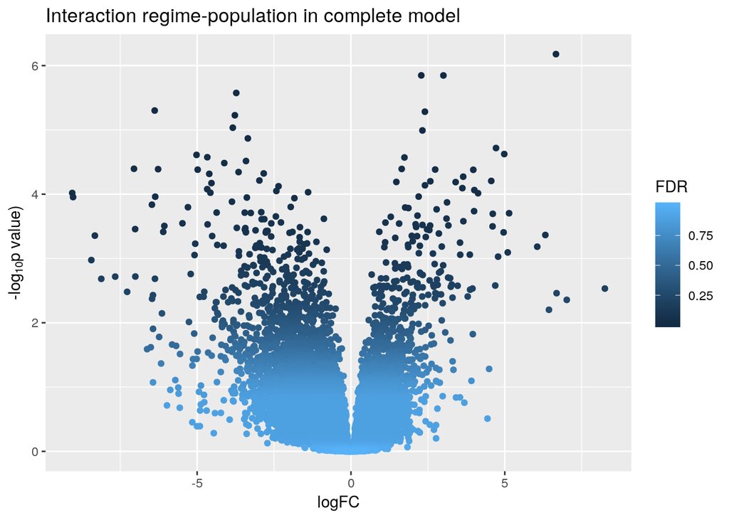

```r
z1 <- topTags(qlf6, n=NumOfTags)$table
z1$logPValue <- -log10(z1$PValue)
z1$logFC <- z1[cbind(1:NumOfTags, apply(abs(z1[,1:4]), 1, which.max))]
ggplot(data=z1, mapping=aes(x=logFC, y=logPValue, color=FDR)) +
   geom_point() + theme_grey() + ylab(expression(paste("-log"[10], plain("p value)")))) +
   ggtitle('Interaction regime-population in complete model')
```

According to model 6, there are 3 tags with a significant interaction term between selective regime and population, at FDR = 0.01.

## Model 4

```r
qlf4 <- glmQLFTest(fit4, coef=4:7)
topTags(qlf4)
```

```
## Coefficient:  regimeregular:NestedPop2 regimerandom:NestedPop2 regimeregular:NestedPop3 regimerandom:NestedPop3
##             logFC.regimeregular.NestedPop2 logFC.regimerandom.NestedPop2
## XLOC_017180                     -0.5392175                   -2.37153382
## XLOC_001420                      0.6577676                    0.20065937
## XLOC_020688                     -2.6977056                    3.00636838
## XLOC_018218                     -0.6082729                   -3.72626438
## XLOC_044910                      1.1190949                   -6.38536151
## XLOC_020921                     -1.0601584                    2.40246321
## XLOC_031557                      0.3167148                   -0.09121439
## XLOC_031928                     -2.6962251                   -3.34303652
## XLOC_044284                      0.2063445                   -3.81403443
## XLOC_016593                     -0.1880893                    2.32665351
##             logFC.regimeregular.NestedPop3 logFC.regimerandom.NestedPop3
## XLOC_017180                    -1.44066224                     6.6580415
## XLOC_001420                     0.22931775                     2.2848926
## XLOC_020688                    -0.92274643                    -0.1803714
## XLOC_018218                     0.03826964                    -1.9735386
## XLOC_044910                     0.79565615                     0.3818658
## XLOC_020921                    -0.41829498                     2.2144309
## XLOC_031557                     0.28812880                    -3.7777783
## XLOC_031928                    -1.27458159                     0.8322147
## XLOC_044284                     0.18373725                    -0.3947533
## XLOC_016593                     0.42231133                     1.1636143
##               logCPM         F       PValue          FDR
## XLOC_017180 2.027386 128.12243 6.655819e-08 0.0009082409
## XLOC_001420 6.601563 111.72571 1.213292e-07 0.0009082409
## XLOC_020688 4.257758 106.88030 1.473062e-07 0.0009082409
## XLOC_018218 4.493302  89.17333 3.246646e-07 0.0015013304
## XLOC_044910 2.179977  77.68291 5.910599e-07 0.0018364137
## XLOC_020921 4.827610  77.54315 5.956902e-07 0.0018364137
## XLOC_031557 4.128825  65.99132 1.196031e-06 0.0031604273
## XLOC_031928 1.352883  59.27867 1.896798e-06 0.0043856351
## XLOC_044284 5.617183  57.54753 2.153752e-06 0.0044264381
## XLOC_016593 4.501495  53.22555 3.007335e-06 0.0055626671
```

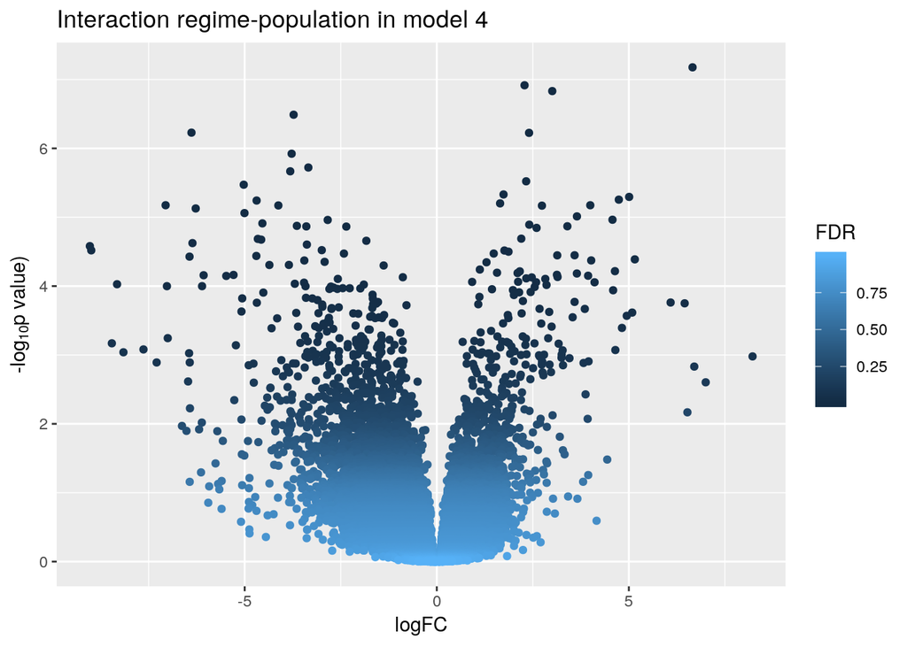

```r
z1 <- topTags(qlf4, n=NumOfTags)$table
z1$logPValue <- -log10(z1$PValue)
z1$logFC <- z1[cbind(1:NumOfTags, apply(abs(z1[,1:4]), 1, which.max))]
ggplot(data=z1, mapping=aes(x=logFC, y=logPValue, color=FDR)) +
   geom_point() + theme_grey() + ylab(expression(paste("-log"[10], plain("p value)")))) +
   ggtitle('Interaction regime-population in model 4')
```

According to model 4, there are 32 tags with a significant interaction term between selective regimew and population, at FDR = 0.01. And this is how the genes identified as having such significant coefficients match between results of models 4 and 6:

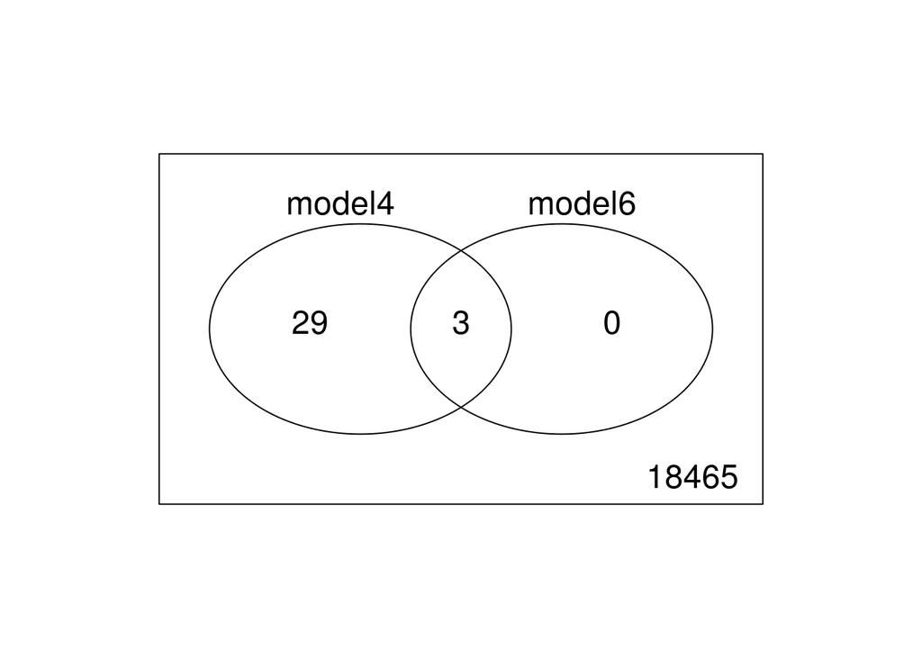

```r
significant <- cbind(model4 = topTags(qlf4, n=NumOfTags, sort.by='none')$table$FDR <= 0.01,
                     model6 = topTags(qlf6, n=NumOfTags, sort.by='none')$table$FDR <= 0.01)
vennDiagram(vennCounts(significant))
```